# Assignment 4 - Start line 73

```python
import pandas as pd
import numpy as np
from sklearn.metrics import confusion_matrix
from sklearn.metrics import classification_report
```

```python
data = pd.read_csv('diabetes_data.csv')
```

```python
data.replace('?', np.nan, inplace=True) # replace '?' to np.nan to understand missing value better
```

#### diag_1, diag_2, diag_3 variables :

The dataset contained upto three diagnoses for a given patient (primary (diag_1), secondary(diag_2) and additional(diag_3)). However, each of these had 700–900 unique ICD codes  
You can collapsed these diagnosis codes into 9 disease categories . These 9 categories include Circulatory, Respiratory, Digestive, Diabetes, Injury, Musculoskeletal, Genitourinary, Neoplasms, and Others.

- You can convert all 3 into 9 categories each. however primary diagnosis is enough for this study.It is upto you!!

ICD9 code conversion reference (Read about it online to understand more)

```python
def convert_diag_codes(code):
#     print (code, type(code))
    if (pd.isnull(code)):
        return 'Other'
    elif ('V' in code) or ('E' in code):
        return 'Other'
    else:
        code = float(code)
        if (code >= 390) and (code < 460) or (np.floor(code)==785):
            return 'Circulatory'
        elif (code >= 460) and (code < 520) or (np.floor(code)==786):
            return 'Respiratory'
        elif (code >= 520) and (code < 580) or (np.floor(code)==787):
            return 'Digestive'
        elif (code == 250):
            return 'Diabetes'
        elif (code >= 800) and (code < 1000):
            return 'Injury'
        elif (code >= 710) and (code < 740):
            return 'Musculoskeletal'
        elif (code >= 580) and (code < 630) or (np.floor(code)==788):
            return 'Genitourinary'
        elif (code >= 140) and (code < 240):
            return 'Neoplasms'
        else:
            return 'Other'
```

```python
data['diag_1'] = data['diag_1'].apply(lambda x:convert_diag_codes(x))
```

### Convert age to numeric

```python
age_dict    = {"[0-10)":5, "[10-20)":15, "[20-30)":25, "[30-40)":35, "[40-50)":45, "[50-60)":55, "[60-70)":65, "[70-80)":75, "[80-90)":85, "[90-100)":95}
data['age'] = data['age'].map(age_dict)
data['age'] = data['age'].astype('int64')
```

### Convert 2 value categories into binary variable

```python
data['change']      = data['change'].replace('Ch', 1)
data['change']      = data['change'].replace('No', 0)
data['diabetesMed'] = data['diabetesMed'].replace('Yes', 1)
data['diabetesMed'] = data['diabetesMed'].replace('No', 0)
```

### Merge categories to one/two level less - Use domain knowledge

```python
data['A1Cresult']     = data['A1Cresult'].replace('>7', 'Abnormal')
data['A1Cresult']     = data['A1Cresult'].replace('>8', 'Abnormal')
data['A1Cresult']     = data['A1Cresult'].replace('Norm', 'Normal')
data['A1Cresult']     = data['A1Cresult'].replace('None', 'Not tested')
data['max_glu_serum'] = data['max_glu_serum'].replace('>200', 'Abnormal')
data['max_glu_serum'] = data['max_glu_serum'].replace('>300', 'Abnormal')
data['max_glu_serum'] = data['max_glu_serum'].replace('Norm', 'Normal')
data['max_glu_serum'] = data['max_glu_serum'].replace('None', 'Not tested')
```

### Merge some categories together - By studying other variables

Admission source, admission type and discharge disposition can help us to understand what theses admission type id corresponds to. For example, admission types 1, 2 and 7 correspond to Emergency, Urgent Care and Trauma, and thus were combined into a single category as these are all non-elective situations.

```python
data['admission_type_id'] = data['admission_type_id'].replace(2,1)
data['admission_type_id'] = data['admission_type_id'].replace(7,1)
data['admission_type_id'] = data['admission_type_id'].replace(6,5)
data['admission_type_id'] = data['admission_type_id'].replace(8,5)
```

### Cautions!! Some columns looks numerical but they are not... Convert them into string

example: admission_type_id, discharge_disposition_id

```python
data['admission_type_id']        = data['admission_type_id'].map(str)
data['discharge_disposition_id'] = data['discharge_disposition_id'].map(str)
```

### Remove duplicate patients; This is creating

- Either simply remove them
- Find a way to deal with them - domain knowledge

```python
data= data.drop_duplicates(subset= ['patient_nbr'], keep = 'first')
```

### Drop columns where values are missing >=40% or have same values, doesn't need for analysis

- You can add or drop more variables from below list

```python
data.drop(['patient_nbr', 'diag_2', 'diag_3', 'encounter_id', 'admission_source_id'], axis = 1, inplace=True)
```

### Check missing value

```python
def cal_missing_val(df):
    data_dict = {}
    for col in df.columns:
        data_dict[col] = (df[col].isnull().sum()/df.shape[0])*100
    return pd.DataFrame.from_dict(data_dict, orient='index', columns=['MissingValueInPercentage'])

cal_missing_val(data)
```

|  | MissingValueInPercentage |
| --- | --- |
| race | 0.0 |
| gender | 0.0 |
| age | 0.0 |
| admission_type_id | 0.0 |
| discharge_disposition_id | 0.0 |
| time_in_hospital | 0.0 |
| num_lab_procedures | 0.0 |
| num_procedures | 0.0 |
| num_medications | 0.0 |
| number_outpatient | 0.0 |
| number_emergency | 0.0 |
| number_inpatient | 0.0 |
| diag_1 | 0.0 |
| number_diagnoses | 0.0 |
| max_glu_serum | 0.0 |
| A1Cresult | 0.0 |
| metformin | 0.0 |
| repaglinide | 0.0 |
| nateglinide | 0.0 |
| chlorpropamide | 0.0 |
| glimepiride | 0.0 |
| acetohexamide | 0.0 |
| glipizide | 0.0 |
| glyburide | 0.0 |
| tolbutamide | 0.0 |
| pioglitazone | 0.0 |
| rosiglitazone | 0.0 |
| acarbose | 0.0 |
| miglitol | 0.0 |
| troglitazone | 0.0 |
| tolazamide | 0.0 |
| insulin | 0.0 |
| glyburide-metformin | 0.0 |
| glipizide-metformin | 0.0 |
| glimepiride-pioglitazone | 0.0 |
| metformin-pioglitazone | 0.0 |
| change | 0.0 |
| diabetesMed | 0.0 |
| readmitted | 0.0 |

### Fill missing value for 'Race'

https://scikit-learn.org/stable/modules/impute.html

```python
## you can be creative here  -- this is for demo purpose
data['race'].replace(np.nan, 'Missing', inplace=True)
```

### Select categorical columns to get_dummies

I have selected 27 columns here..

```python
categorical_cols = ['gender','race','admission_type_id','discharge_disposition_id','diag_1', 'max_glu_serum', 'A1Cresult', 'metformin',
     'repaglinide', 'nateglinide', 'chlorpropamide', 'glimepiride', 'acetohexamide', 'glipizide', 'glyburide', 'tolbutamide',
     'pioglitazone', 'rosiglitazone', 'acarbose', 'miglitol', 'troglitazone', 'tolazamide', 'insulin', 'glyburide-metformin',
     'glipizide-metformin', 'glimepiride-pioglitazone', 'metformin-pioglitazone']
```

### Convert to dummies

```python
data_dummies = pd.get_dummies(data[categorical_cols], drop_first=True)
```

```python
data_dummies.head(5)
```

|  | gender_Male | gender_Unknown/Invalid | race_Asian | race_Caucasian | race_Hispanic | race_Other | admission_type_id_3 | admission_type_id_4 | admission_type_id_5 | discharge_disposition_id_10 | ... | troglitazone_Steady | tolazamide_Steady | insulin_No | insulin_Steady | insulin_Up | glyburide-metformin_No | glyburide-metformin_Steady | glyburide-metformin_Up | glipizide-metformin_Steady | metformin-pioglitazone_Steady |
| --- | --- | --- | --- | --- | --- | --- | --- | --- | --- | --- | --- | --- | --- | --- | --- | --- | --- | --- | --- | --- | --- |
| 0 | 0 | 0 | 0 | 1 | 0 | 0 | 0 | 0 | 0 | 0 | ... | 0 | 0 | 0 | 0 | 1 | 1 | 0 | 0 | 0 | 0 |
| 1 | 0 | 0 | 0 | 0 | 0 | 0 | 0 | 0 | 0 | 0 | ... | 0 | 0 | 1 | 0 | 0 | 1 | 0 | 0 | 0 | 0 |
| 2 | 1 | 0 | 0 | 1 | 0 | 0 | 0 | 0 | 0 | 0 | ... | 0 | 0 | 0 | 0 | 1 | 1 | 0 | 0 | 0 | 0 |
| 3 | 1 | 0 | 0 | 1 | 0 | 0 | 0 | 0 | 0 | 0 | ... | 0 | 0 | 0 | 1 | 0 | 1 | 0 | 0 | 0 | 0 |
| 4 | 1 | 0 | 0 | 1 | 0 | 0 | 0 | 0 | 0 | 0 | ... | 0 | 0 | 0 | 1 | 0 | 1 | 0 | 0 | 0 | 0 |

5 rows × 90 columns

### Change readmitted (response variable) into binary variable

```python
readmit_dict = {'>30':1, '<30':1, 'NO':0}
data['readmitted'] = data['readmitted'].map(readmit_dict)
```

### Merge dummies with numerical cols

```python
noncategorical_cols = [col for col in data.columns if col not in categorical_cols]
noncategorical_cols
```

```
['age',
 'time_in_hospital',
 'num_lab_procedures',
 'num_procedures',
 'num_medications',
 'number_outpatient',
 'number_emergency',
 'number_inpatient',
 'number_diagnoses',
 'change',
 'diabetesMed',
 'readmitted']
```

```python
data_preprocess = pd.concat([data[noncategorical_cols], data_dummies], axis=1)
```

```python
data_preprocess.shape # this is a dataset ready for further analysis
```

```
(68630, 102)
```

```python
data_preprocess.to_csv('diabetes_data_preprocess.csv', index=False) ## R user can use this file
```

#### I think 100-120 columns are pretty good to work with. You can run this analysis both in R/Python very smoothly

# Asignments 4 Part 1

1. Use diabetes dataset from canvas. Readmitted is dependent variable.

```python
data_preprocess.head()
data_preprocess.dtypes
```

```
age                              int64
time_in_hospital                 int64
num_lab_procedures               int64
num_procedures                   int64
num_medications                  int64
                                 ...
glyburide-metformin_No           uint8
glyburide-metformin_Steady       uint8
glyburide-metformin_Up           uint8
glipizide-metformin_Steady       uint8
metformin-pioglitazone_Steady    uint8
Length: 102, dtype: object
```

```python
data_preprocess.dtypes
```

```
age                              int64
time_in_hospital                 int64
num_lab_procedures               int64
num_procedures                   int64
num_medications                  int64
                                 ...
glyburide-metformin_No           uint8
glyburide-metformin_Steady       uint8
glyburide-metformin_Up           uint8
glipizide-metformin_Steady       uint8
metformin-pioglitazone_Steady    uint8
Length: 102, dtype: object
```

```python
data_preprocess[data_preprocess.columns[data_preprocess.dtypes=='object']]
```

| 0 |
| --- |
| 1 |
| 2 |
| 3 |
| 4 |
| ... |
| 98041 |
| 98042 |
| 98043 |
| 98045 |
| 98052 |

68630 rows × 0 columns

2 Merge the < 30 days and > 30 days values to “Yes”. For logistic regression dependent variable should be binary.

```python
# column is changed from above code provided
data_preprocess['readmitted'].head()
```

```
0    1
1    0
2    0
3    0
4    1
Name: readmitted, dtype: int64
```

1. Dummy/oneHot encode categorical variables. (One hot encode on whole dataset and then use for splitting)

```python
# column is changed from above code provided
data_preprocess.head()
```

|  | age | time_in_hospital | num_lab_procedures | num_procedures | num_medications | number_outpatient | number_emergency | number_inpatient | number_diagnoses | change | ... | troglitazone_Steady | tolazamide_Steady | insulin_No | insulin_Steady | insulin_Up | glyburide-metformin_No | glyburide-metformin_Steady | glyburide-metformin_Up | glipizide-metformin_Steady | metformin-pioglitazone_Steady |
| --- | --- | --- | --- | --- | --- | --- | --- | --- | --- | --- | --- | --- | --- | --- | --- | --- | --- | --- | --- | --- | --- |
| 0 | 15 | 3 | 59 | 0 | 18 | 0 | 0 | 0 | 9 | 1 | ... | 0 | 0 | 0 | 0 | 1 | 1 | 0 | 0 | 0 | 0 |
| 1 | 25 | 2 | 11 | 5 | 13 | 2 | 0 | 1 | 6 | 0 | ... | 0 | 0 | 1 | 0 | 0 | 1 | 0 | 0 | 0 | 0 |
| 2 | 35 | 2 | 44 | 1 | 16 | 0 | 0 | 0 | 7 | 1 | ... | 0 | 0 | 0 | 0 | 1 | 1 | 0 | 0 | 0 | 0 |
| 3 | 45 | 1 | 51 | 0 | 8 | 0 | 0 | 0 | 5 | 1 | ... | 0 | 0 | 0 | 1 | 0 | 1 | 0 | 0 | 0 | 0 |
| 4 | 55 | 3 | 31 | 6 | 16 | 0 | 0 | 0 | 9 | 0 | ... | 0 | 0 | 0 | 1 | 0 | 1 | 0 | 0 | 0 | 0 |

5 rows × 102 columns

1. Separate dataset into train and test samples (70:30). Using set.seed (R)/ random_state (Python) while splitting. SAVE THESE SAMPLES. You will need same test and train for next assignments to compare results.

```python
from sklearn.model_selection import train_test_split
```

```python
Xtrain, Xtest,Ytrain,Ytest = train_test_split(data_preprocess.loc[:,
data_preprocess.columns != 'readmitted'], data_preprocess['readmitted'],test_size=0.3,random_state = 1234)
```

```python
Xtrain.head()
```

|  | age | time_in_hospital | num_lab_procedures | num_procedures | num_medications | number_outpatient | number_emergency | number_inpatient | number_diagnoses | change | ... | troglitazone_Steady | tolazamide_Steady | insulin_No | insulin_Steady | insulin_Up | glyburide-metformin_No | glyburide-metformin_Steady | glyburide-metformin_Up | glipizide-metformin_Steady | metformin-pioglitazone_Steady |
| --- | --- | --- | --- | --- | --- | --- | --- | --- | --- | --- | --- | --- | --- | --- | --- | --- | --- | --- | --- | --- | --- |
| 79142 | 65 | 1 | 1 | 4 | 23 | 0 | 0 | 0 | 9 | 1 | ... | 0 | 0 | 1 | 0 | 0 | 1 | 0 | 0 | 0 | 0 |
| 16814 | 55 | 6 | 62 | 1 | 34 | 0 | 0 | 0 | 9 | 1 | ... | 0 | 0 | 0 | 0 | 0 | 1 | 0 | 0 | 0 | 0 |
| 34360 | 55 | 5 | 46 | 3 | 52 | 0 | 0 | 1 | 7 | 1 | ... | 0 | 0 | 0 | 0 | 1 | 1 | 0 | 0 | 0 | 0 |
| 21780 | 65 | 3 | 59 | 1 | 17 | 0 | 0 | 0 | 9 | 0 | ... | 0 | 0 | 0 | 1 | 0 | 1 | 0 | 0 | 0 | 0 |
| 36819 | 75 | 1 | 31 | 6 | 9 | 0 | 0 | 0 | 4 | 1 | ... | 0 | 0 | 0 | 0 | 1 | 1 | 0 | 0 | 0 | 0 |

5 rows × 101 columns

```python
Xtrain.dtypes
```

```
age                              int64
time_in_hospital                 int64
num_lab_procedures               int64
num_procedures                   int64
num_medications                  int64
                                 ...
glyburide-metformin_No           uint8
glyburide-metformin_Steady       uint8
glyburide-metformin_Up           uint8
glipizide-metformin_Steady       uint8
metformin-pioglitazone_Steady    uint8
Length: 101, dtype: object
```

```python
Ytest.dtypes
```

```
dtype('int64')
```

##### 5. Build logistic regression model on Train Data set - Use below steps for reference.

##### Use sklearn.linear_model.LogisticRegression OR discrete.discrete_model

#### Use cross validation, parameter tuning (penalty, c) in sklearn package

#### Select best variables by looking at coefficients of variables and fit model with best variables and best parameters

```python
from sklearn.linear_model import LogisticRegression
```

```python
model1 = LogisticRegression(random_state = 1234, max_iter  = 10000000000,C = 100000).fit(Xtrain,Ytrain)
```

```python
model1.score(Xtrain,Ytrain)
```

```
0.6276305655585854
```

```python
model1.get_params()
```

```
{'C': 100000,
 'class_weight': None,
 'dual': False,
 'fit_intercept': True,
 'intercept_scaling': 1,
 'l1_ratio': None,
 'max_iter': 10000000000,
 'multi_class': 'auto',
 'n_jobs': None,
 'penalty': 'l2',
 'random_state': 1234,
 'solver': 'lbfgs',
 'tol': 0.0001,
 'verbose': 0,
 'warm_start': False}
```

```python
model2 = LogisticRegression(random_state = 1234, penalty = 'none', max_iter  = 10000000000).fit(Xtrain,Ytrain)
```

```python
model2.score(Xtrain,Ytrain)
```

```
0.6280676921795966
```

```python
y_test_pred = model2.predict(Xtest)

print("The Classification table for the train set is:\n", confusion_matrix(Ytest, y_test_pred ))
print(classification_report(Ytest, y_test_pred))
```

```
The Classification table for the train set is:
 [[10760  1436]
 [ 6266  2127]]
              precision    recall  f1-score   support

           0       0.63      0.88      0.74     12196
           1       0.60      0.25      0.36      8393

    accuracy                           0.63     20589
   macro avg       0.61      0.57      0.55     20589
weighted avg       0.62      0.63      0.58     20589
```

```python
coef = pd.DataFrame(abs(model2.coef_[0]),index= Xtrain.columns).sort_values(by=0,ascending=False)
coef.head(10)
```

|  | 0 |
| --- | --- |
| discharge_disposition_id_11 | 8.027250 |
| discharge_disposition_id_14 | 3.056119 |
| discharge_disposition_id_13 | 2.075466 |
| discharge_disposition_id_15 | 1.731839 |
| discharge_disposition_id_24 | 1.219626 |
| miglitol_No | 0.910353 |
| rosiglitazone_Steady | 0.822057 |
| pioglitazone_No | 0.717526 |
| discharge_disposition_id_19 | 0.671268 |
| rosiglitazone_No | 0.662213 |

```python
significant = ['discharge_disposition_id_11','discharge_disposition_id_14','discharge_disposition_id_13',
              'discharge_disposition_id_15','discharge_disposition_id_24','miglitol_No','rosiglitazone_Steady',
              'pioglitazone_No','discharge_disposition_id_19','rosiglitazone_No']
```

```python
model3 = LogisticRegression(random_state = 1234, penalty = 'none', max_iter  = 10000000000).fit(Xtrain[significant],Ytrain)
```

```python
model3.score(Xtrain[significant],Ytrain)
```

```
0.5974688287088112
```

```python
model4 = LogisticRegression(random_state = 1234, max_iter  = 10000000000,C = 100000).fit(Xtrain[significant],Ytrain)
```

```python
model4.score(Xtrain[significant],Ytrain)
```

```
0.5974688287088112
```

#### 6. Generate confusion matrix on train dataset. What function can we use for this? Table (predictions, actual readmitted colums), metrics.confusion_matrix Consider what your classification bound should be. Standard is 0.5. Is there an argument for choosing something different? Try some heuristic to change threshold for probabilities– does it improve your overall accuracy?

```python
from sklearn.metrics import classification_report
from sklearn import metrics
import scikitplot as scplt
import matplotlib.pyplot as plt
```

```python
y_train_pred = model4.predict(Xtrain[significant])

print("The Classification table for the train set is:\n", confusion_matrix(Ytrain, y_train_pred ))
```

```
The Classification table for the train set is:
 [[28674    10]
 [19328    29]]
```

```python
print(classification_report(Ytrain, y_train_pred))
```

```
              precision    recall  f1-score   support

           0       0.60      1.00      0.75     28684
           1       0.74      0.00      0.00     19357

    accuracy                           0.60     48041
   macro avg       0.67      0.50      0.38     48041
weighted avg       0.66      0.60      0.45     48041
```

```python
y_train_pred = (model4.predict_proba(Xtrain[significant])[:, 1] > 0.3).astype('int')

print("The Classification table for the test set is:\n", confusion_matrix(Ytrain, y_train_pred))
print(classification_report(Ytrain,y_train_pred))
```

```
The Classification table for the test set is:
 [[ 1022 27662]
 [   26 19331]]
              precision    recall  f1-score   support

           0       0.98      0.04      0.07     28684
           1       0.41      1.00      0.58     19357

    accuracy                           0.42     48041
   macro avg       0.69      0.52      0.33     48041
weighted avg       0.75      0.42      0.28     48041
```

```python
y_train_pred = (model4.predict_proba(Xtrain[significant])[:, 1] > 0.8).astype('int')

print("The Classification table for the test set is:\n", confusion_matrix(Ytrain, y_train_pred))
print(classification_report(Ytrain,y_train_pred))
```

```
The Classification table for the test set is:
 [[28683     1]
 [19354     3]]
              precision    recall  f1-score   support

           0       0.60      1.00      0.75     28684
           1       0.75      0.00      0.00     19357

    accuracy                           0.60     48041
   macro avg       0.67      0.50      0.37     48041
weighted avg       0.66      0.60      0.45     48041
```

Changing the threshold does not really increase the accuracy for the model. Accuracy is actually reduced for threshold 0.3. However, when threshold is 0.3 not that many false negative are produced. This is better than the other two threshold because it can help hospitals to correctly predict patients. Therefore, 0.3 is the best classification bound

#### 7. After you’ve decided your classification bound, predict test results and assign ‘No’ or ‘Yes’ to each observation based on your classification bound. Type = “class”. Generate confusion matrix on test set.

```python
y_test_pred = (model4.predict_proba(Xtest[significant])[:, 1] > 0.3).astype('int')

print("The Classification table for the test set is:\n", confusion_matrix(Ytest, y_test_pred))
print(classification_report(Ytest,y_test_pred))
```

```
The Classification table for the test set is:
 [[  480 11716]
 [   13  8380]]
              precision    recall  f1-score   support

           0       0.97      0.04      0.08     12196
           1       0.42      1.00      0.59      8393

    accuracy                           0.43     20589
   macro avg       0.70      0.52      0.33     20589
weighted avg       0.75      0.43      0.28     20589
```

```python
y_test_pred
```

```
array([1, 1, 1, ..., 1, 1, 1])
```

```python
y_test_pred = np.where(y_test_pred == 1,'Yes','No').astype('object')
```

```python
Ytestyes = np.where(Ytest== 1,'Yes','No').astype('object')
```

```python
print(Ytest)
print(y_test_pred)
y_test_pred.dtype
Ytestyes.dtype
```

```
82922    1
50603    0
17239    0
23900    0
34492    1
        ..
56552    0
24793    1
2307     0
75513    1
51557    0
Name: readmitted, Length: 20589, dtype: int64
['Yes' 'Yes' 'Yes' ... 'Yes' 'Yes' 'Yes']
```

```
dtype('O')
```

```python
print("The Classification table for the test set is:\n", confusion_matrix(Ytestyes, y_test_pred))
print(classification_report(Ytestyes,y_test_pred))
```

```
The Classification table for the test set is:
 [[  480 11716]
 [   13  8380]]
              precision    recall  f1-score   support

          No       0.97      0.04      0.08     12196
         Yes       0.42      1.00      0.59      8393

    accuracy                           0.43     20589
   macro avg       0.70      0.52      0.33     20589
weighted avg       0.75      0.43      0.28     20589
```

#### 8. Compare proportion of 0s (No) and 1s (Yes) predicted correctly in train and test. Is there stability?

```python
y_train_pred = (model4.predict_proba(Xtrain[significant])[:, 1] > 0.3).astype('int')

print("The Classification table for the test set is:\n", confusion_matrix(Ytrain, y_train_pred))
print(classification_report(Ytrain,y_train_pred))
```

```
The Classification table for the test set is:
 [[ 1022 27662]
 [   26 19331]]
              precision    recall  f1-score   support

           0       0.98      0.04      0.07     28684
           1       0.41      1.00      0.58     19357

    accuracy                           0.42     48041
   macro avg       0.69      0.52      0.33     48041
weighted avg       0.75      0.42      0.28     48041
```

There is stability. The precision between train and test are very similar. The accuracy between the train and the test are also very similar

#### 10. Plot ROC Curve. Plot of sensitivity vs. power (1-specificity). Main diagonal line is random, coin flip model. The further our curve is from this line, the better. Max AUC = 1.

Note: Gains chart and ROC curve require probabilities as input.

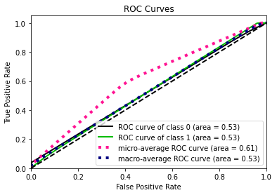

```
The AUC Value for the model is 0.527610469093765
```

```python
predictions_test_prob=model4.predict_proba(Xtest[significant])

fpr, tpr, tholds = metrics.roc_curve(Ytest, predictions_test_prob[:,1], pos_label = 1)
scplt.metrics.plot_roc(Ytest, predictions_test_prob)
plt.show()

print("The AUC Value for the model is", metrics.auc(fpr, tpr))
```

# Assignment 4 Part 2

#### 1. Use same train and test sample from logistic regression (assignment 4.1). You can either consider readmitted as 1) 'binary' -Yes/No or 2)'Multi-Class' - >30, <30, No. For second scenario, you need to use 'readmitted' variable before merging from Assignment 4.1 Step 2. Make a judgement call here

```python
Xtrain.head()
```

|  | age | time_in_hospital | num_lab_procedures | num_procedures | num_medications | number_outpatient | number_emergency | number_inpatient | number_diagnoses | change | ... | troglitazone_Steady | tolazamide_Steady | insulin_No | insulin_Steady | insulin_Up | glyburide-metformin_No | glyburide-metformin_Steady | glyburide-metformin_Up | glipizide-metformin_Steady | metformin-pioglitazone_Steady |
| --- | --- | --- | --- | --- | --- | --- | --- | --- | --- | --- | --- | --- | --- | --- | --- | --- | --- | --- | --- | --- | --- |
| 79142 | 65 | 1 | 1 | 4 | 23 | 0 | 0 | 0 | 9 | 1 | ... | 0 | 0 | 1 | 0 | 0 | 1 | 0 | 0 | 0 | 0 |
| 16814 | 55 | 6 | 62 | 1 | 34 | 0 | 0 | 0 | 9 | 1 | ... | 0 | 0 | 0 | 0 | 0 | 1 | 0 | 0 | 0 | 0 |
| 34360 | 55 | 5 | 46 | 3 | 52 | 0 | 0 | 1 | 7 | 1 | ... | 0 | 0 | 0 | 0 | 1 | 1 | 0 | 0 | 0 | 0 |
| 21780 | 65 | 3 | 59 | 1 | 17 | 0 | 0 | 0 | 9 | 0 | ... | 0 | 0 | 0 | 1 | 0 | 1 | 0 | 0 | 0 | 0 |
| 36819 | 75 | 1 | 31 | 6 | 9 | 0 | 0 | 0 | 4 | 1 | ... | 0 | 0 | 0 | 0 | 1 | 1 | 0 | 0 | 0 | 0 |

5 rows × 101 columns

```python
Ytest.head()
```

```
82922    1
50603    0
17239    0
23900    0
34492    1
Name: readmitted, dtype: int64
```

#### 2. Build a full classification tree using the train data and all variables.

```python
from sklearn.tree import DecisionTreeClassifier
from sklearn.model_selection import GridSearchCV
```

```python
treemodel1 = DecisionTreeClassifier(random_state=1234)
treemodel1.fit(Xtrain,Ytrain)
```

```
DecisionTreeClassifier(random_state=1234)
```

```python
treemodel1.get_params()
```

```
{'ccp_alpha': 0.0,
 'class_weight': None,
 'criterion': 'gini',
 'max_depth': None,
 'max_features': None,
 'max_leaf_nodes': None,
 'min_impurity_decrease': 0.0,
 'min_impurity_split': None,
 'min_samples_leaf': 1,
 'min_samples_split': 2,
 'min_weight_fraction_leaf': 0.0,
 'presort': 'deprecated',
 'random_state': 1234,
 'splitter': 'best'}
```

```python
treemodel1.score(Xtrain,Ytrain)
```

```
0.9999375533398556
```

#### 2. Perform GridSearchCv on DecisionTreeClassifier parameters (‘max_depth’, ‘criterion’, ‘max_features’, ‘max_leaf_nodes’ etc..)

#### Use 5 - 10 fold cross validation

```python
grid = {
    "max_depth":[2,5,10,15,20], "criterion": ('gini', 'entropy'), "splitter": ('best', 'random'),
    'min_samples_split': [2,5,10,15,20],
    'max_features':[5,10,15]
}
```

```python
tree = DecisionTreeClassifier(random_state = 1234)
gridmodel = GridSearchCV(tree, grid, cv=6)
gridmodel.fit(Xtrain,Ytrain)
```

```
GridSearchCV(cv=6, estimator=DecisionTreeClassifier(random_state=1234),
             param_grid={'criterion': ('gini', 'entropy'),
                         'max_depth': [2, 5, 10, 15, 20],
                         'max_features': [5, 10, 15],
                         'min_samples_split': [2, 5, 10, 15, 20],
                         'splitter': ('best', 'random')})
```

#### Select best parameters and important features (10-20) from selected model

```python
gridmodel.best_params_
```

```
{'criterion': 'gini',
 'max_depth': 10,
 'max_features': 15,
 'min_samples_split': 10,
 'splitter': 'best'}
```

```python
besttree = DecisionTreeClassifier(criterion ='gini',
            max_depth= 10, splitter='best',max_features= 15, random_state=1234)
besttree.fit(Xtrain,Ytrain)
```

```
DecisionTreeClassifier(max_depth=10, max_features=15, random_state=1234)
```

```python
treecoef = pd.DataFrame(besttree.feature_importances_,index= Xtrain.columns,
                        columns=['coefficient']).sort_values(by='coefficient',ascending = False)
treecoef.head(15)
```

|  | coefficient |
| --- | --- |
| number_inpatient | 0.222739 |
| discharge_disposition_id_11 | 0.142069 |
| number_outpatient | 0.088385 |
| num_medications | 0.067310 |
| age | 0.055943 |
| discharge_disposition_id_6 | 0.044409 |
| num_lab_procedures | 0.044227 |
| admission_type_id_5 | 0.030293 |
| diabetesMed | 0.029826 |
| insulin_No | 0.025992 |
| number_diagnoses | 0.025436 |
| time_in_hospital | 0.024470 |
| number_emergency | 0.019225 |
| num_procedures | 0.016038 |
| discharge_disposition_id_13 | 0.015830 |

```python
tree_sig = ['number_inpatient','discharge_disposition_id_11','number_outpatient','num_medications',
            'age','discharge_disposition_id_6','num_lab_procedures','admission_type_id_5','diabetesMed',
            'insulin_No','number_diagnoses','time_in_hospital','number_emergency','num_procedures',
           'discharge_disposition_id_13']
```

#### Build a best model on train dataset

```python
besttree.fit(Xtrain[tree_sig],Ytrain)
bestmodel = besttree.fit(Xtrain[tree_sig],Ytrain)
```

```python
train_pred = besttree.predict(Xtrain[tree_sig])
```

#### Generate confusion matrix on train

```python
print(confusion_matrix(Ytrain, train_pred ))

print(classification_report(Ytrain, train_pred))
```

```
[[25732  2952]
 [14275  5082]]
              precision    recall  f1-score   support

           0       0.64      0.90      0.75     28684
           1       0.63      0.26      0.37     19357

    accuracy                           0.64     48041
   macro avg       0.64      0.58      0.56     48041
weighted avg       0.64      0.64      0.60     48041
```

#### Plot tree using pydotplus , export_graphviz package

```python
from sklearn.tree import DecisionTreeClassifier
from sklearn.model_selection import GridSearchCV
from sklearn.model_selection import RandomizedSearchCV

import pydotplus
from six import StringIO
from sklearn.tree import export_graphviz
from IPython.display import Image
```

```python
tree_dot = StringIO()

tree_clf = DecisionTreeClassifier(max_depth=5)
tree_clf.fit(Xtest[tree_sig], Ytestyes)
print(tree_clf.predict(Xtest[tree_sig]))
print(tree_clf.score(Xtest[tree_sig], Ytestyes))
```

```
['No' 'No' 'No' ... 'No' 'No' 'No']
0.6242653844285784
```

```python
export_graphviz(
  tree_clf,
  out_file = tree_dot,
  feature_names=Xtest[tree_sig].columns,
  class_names=Ytestyes,
  rounded=True,
  filled=True
 )
```

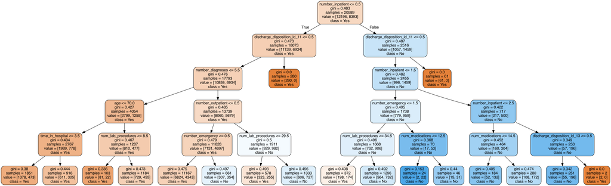

```python
tree_graph = pydotplus.graph_from_dot_data(tree_dot.getvalue())
Image(tree_graph.create_png())
```

#### Point out significant interactions you think you see

One interaction i see is the number_emergency<=0.5 and the num_lab_procedures at the bottom of the praph. The value predicted is not that accurate. In addition, this makes sense because patients will have more lab_procedures when they have emergency. The second interactions i see is the num_lab_procedures and num_medications. This also makes sense because we expect patients to take more medications after they finished lab procedures.

#### 4. Predict values for test data and compare confusion matrix with train. Type = “class” (R), and predict (Python) Are results stable?

```python
test_pred = bestmodel.predict(Xtest[tree_sig])
```

```python
print(confusion_matrix(Ytest, test_pred ))

print(classification_report(Ytest, test_pred))
```

```
[[10754  1442]
 [ 6366  2027]]
              precision    recall  f1-score   support

           0       0.63      0.88      0.73     12196
           1       0.58      0.24      0.34      8393

    accuracy                           0.62     20589
   macro avg       0.61      0.56      0.54     20589
weighted avg       0.61      0.62      0.57     20589
```

```python
print(confusion_matrix(Ytrain, train_pred ))

print(classification_report(Ytrain, train_pred))
```

```
[[25732  2952]
 [14275  5082]]
              precision    recall  f1-score   support

           0       0.64      0.90      0.75     28684
           1       0.63      0.26      0.37     19357

    accuracy                           0.64     48041
   macro avg       0.64      0.58      0.56     48041
weighted avg       0.64      0.64      0.60     48041
```

#### 5.Compare Test results for logistic regression and classification tree by comparing the two confusion matrices. If you have used multiclass decision tree model then you need to combine >30 and <30 category as 'Yes' in confusion matrix for comparison. What do your proportion of predicted 0s (No) and 1s (Yes) say about what kind of insights/solutions each of these methods is giving you?

```python
print('The result from Logistic Regression')
print("The Classification table for the test set is:\n", confusion_matrix(Ytestyes, y_test_pred))
print(classification_report(Ytestyes,y_test_pred))
```

```
The result from Logistic Regression
The Classification table for the test set is:
 [[  480 11716]
 [   13  8380]]
              precision    recall  f1-score   support

          No       0.97      0.04      0.08     12196
         Yes       0.42      1.00      0.59      8393

    accuracy                           0.43     20589
   macro avg       0.70      0.52      0.33     20589
weighted avg       0.75      0.43      0.28     20589
```